# Divorces in Canada, Data Analysis

Jeremy Friesen, 2018-12-10

These data sources are interesting and relevant because divorces can say a lot about our society. Divorces are the legal termination of marriage, and statistics about them can describe the breakdown of long term relationships.

Let's start by importing the necessary packages:

```python
import numpy as np
import pandas as pd
import matplotlib.pyplot as pl
from matplotlib.legend_handler import HandlerLine2D
%matplotlib inline
```

## Divorce Rates by Year of Marriage

As a starting point, let's look at divorce rates by the year the couples were married.

```python
divorceRatesByYearOfMarriage = pd.read_csv('divorceRatesByYearOfMarriage.csv')
# print the size of the dataset
print(divorceRatesByYearOfMarriage.shape)

# Trim the ", place of occurence" substring from the GEO column
divorceRatesByYearOfMarriage['GEO'] = divorceRatesByYearOfMarriage['GEO'].str.partition(',')[0]

# Set the index to the year of marriage
divorceRatesByYearOfMarriage = divorceRatesByYearOfMarriage.set_index('Year of marriage').sort_index(0)
```

```
(650, 15)
```

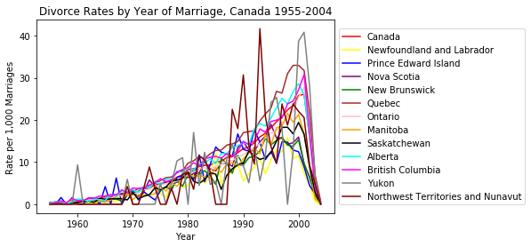

```python
# Graph each province/territory's Divorce Rates by Year of Marriage
GEOs = ['Canada', 'Newfoundland and Labrador', 'Prince Edward Island', 'Nova Scotia', 'New Brunswick', 'Quebec', 'Ontario',
        'Manitoba', 'Saskatchewan', 'Alberta', 'British Columbia', 'Yukon', 'Northwest Territories and Nunavut']
colors = ['red', 'yellow', 'blue', 'purple', 'green', 'brown', 'pink', 'orange', 'black', 'cyan', 'magenta', 'gray',
           'maroon']

for i in range(len(GEOs)):
    pl.plot(divorceRatesByYearOfMarriage[divorceRatesByYearOfMarriage['GEO'] == GEOs[i]]['VALUE'], color=colors[i]);

pl.title("Divorce Rates by Year of Marriage, Canada 1955-2004")
pl.legend(GEOs, loc='center left', bbox_to_anchor=(1.0, 0.5))
pl.xlabel("Year");
pl.ylabel("Rate per 1,000 Marriages");
```

## Graph Analysis

There seems to be a significant upwards trend on the graphs for each province/territory and Canada as a whole. There's a few 0's in the data as well, which likely just means the data for those years is unreported.

The data seems to peak at around 2000. Since this data was published in 2004, couples married since 2000 would have been married less than 4 years, and possibly less likely to get divorced because of the short span of time they have been married.

To test this, let's analyze data which reports divorce rates by length of marriage.

```python
divorcesByDurationOfMarriage = pd.read_csv('divorcesByDurationOfMarriage.csv')
# print the size of the dataset
print(divorcesByDurationOfMarriage.shape)

divorcesByDOM = divorcesByDurationOfMarriage

# Trim the ", place of occurrence" substring from the 'GEO' column
divorcesByDOM['GEO'] = divorcesByDurationOfMarriage['GEO'].str.partition(',')[0]

# Trim the "Duration of marriage," substring from the 'Duration of marriage' column
divorcesByDOM.loc[:, 'Duration of marriage'] = divorcesByDOM['Duration of marriage'].str.partition(',')[2]

# Filters data so that the 'Duration of marriage' column will only have exct year values
divorcesByDOM = divorcesByDOM[(divorcesByDOM['Duration of marriage'].str.find('to') == -1) &
                              (divorcesByDOM['Duration of marriage'].str.find('all years') == -1) &
                              (divorcesByDOM['Duration of marriage'].str.find('not stated') == -1) &
                              (divorcesByDOM['Duration of marriage'].str.find('and over') == -1)]
```

```
(1204, 15)
```

### The graph for divorces by duration of marriage for all of Canada(2005) looks like this:

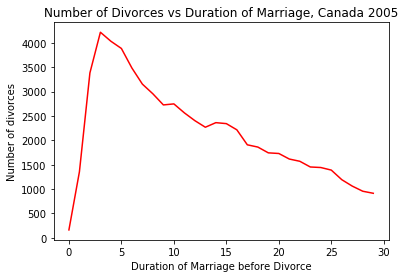

```python
canadaDivorcesByDOM = divorcesByDOM[(divorcesByDOM['GEO'] == 'Canada') & (divorcesByDOM['REF_DATE'] == 2005)]
xs = canadaDivorcesByDOM['Duration of marriage'].str.partition(' ')[2].str.partition(' ')[0]
ys = canadaDivorcesByDOM['VALUE']
pl.plot(xs, ys, color='red');

pl.xlabel('Duration of Marriage before Divorce')
pl.ylabel('Number of divorces')
pl.title('Number of Divorces vs Duration of Marriage, Canada 2005');
```

The graph shows a sharp incline in the first few years after marriage, then a gradual decline in divorces with higher marriage durations.

```python
canadaDivorces = divorcesByDurationOfMarriage
canadaDivorces['GEO'] = divorcesByDurationOfMarriage['GEO'].str.partition(',')[0]
canadaDivorces = canadaDivorces[(canadaDivorces['GEO'] == 'Canada') & (canadaDivorces['REF_DATE'] == 2005)]

# Removing unnecessary categories
canadaDivorces = canadaDivorces[(canadaDivorces['Duration of marriage'].str.find('1 to 4') == -1) &
                              (canadaDivorces['Duration of marriage'].str.find('5 to 9') == -1) &
                              (canadaDivorces['Duration of marriage'].str.find('10 to 14') == -1) &
                              (canadaDivorces['Duration of marriage'].str.find('15 to 19') == -1) &
                              (canadaDivorces['Duration of marriage'].str.find('20 to 24') == -1) &
                              (canadaDivorces['Duration of marriage'].str.find('25 to 29') == -1) &
                              (canadaDivorces['Duration of marriage'].str.find('all years') == -1) &
                               (canadaDivorces['Duration of marriage'].str.find('not') == -1)]

xs = canadaDivorces['Duration of marriage']
xs = list(map(int, xs.str.partition(' ')[2].str.partition(' ')[0].values))
ys = canadaDivorces['VALUE']

#pl.plot(xs, ys);
#canadaDivorces['Duration of marriage'].str.partition(' ')[2].str.partition(' ')[0]
```

## Divorces, by reason for marital breakdown

To gain more insight, let's look at a dataset which covers the reason for divorce.

```python
divorcesByReason = pd.read_csv('divorcesByReason.csv')
# print the size of the dataset
print(divorcesByReason.shape)

#Trimming ', reason for marital breakdown' substring from 'Reason for marital breakdown' column
divorcesByReason['Reason for marital breakdown'] = divorcesByReason['Reason for marital breakdown'].str.partition(',')[2]
divorcesByReason.loc[divorcesByReason['Reason for marital breakdown'] == ' reason for marital breakdown',
                                                                          'Reason for marital breakdown'] = 'total'

#Trimming ', place of occurence' substring from 'GEO' column
divorcesByReason['GEO'] = divorcesByReason['GEO'].str.partition(',')[0]
```

```
(140, 15)
```

[figure not shown]

```python
divByR = divorcesByReason.sort_values('VALUE', ascending=False)
xs = divByR.loc[(divByR['GEO'] == 'Canada') & (divByR['REF_DATE'] == 2005)
                & (divByR['Reason for marital breakdown'] != 'total')].index
ys = divByR.loc[(divByR['GEO'] == 'Canada') & (divByR['REF_DATE'] == 2005)
                & (divByR['Reason for marital breakdown'] != 'total'), 'VALUE']
colors = ['blue', 'red', 'green', 'orange']
reasons = ['separation for at\nleast one year', 'adultery', 'physical\ncruelty', 'mental\ncruelty']

reasonPlot = pl.bar(xs, ys, color=colors)
pl.xticks(xs, reasons)
pl.ylabel("Number of Divorces");
pl.title('Number of Divorces vs Reason for Marital Breakdown,\nCanada 2005');
```

## Number of Divorces By Year

```python
vitalStatsDivorce = pd.read_csv('vitalStatsDivorce.csv')
# print the size of the dataset
print(vitalStatsDivorce.shape)
```

```
(446, 15)
```

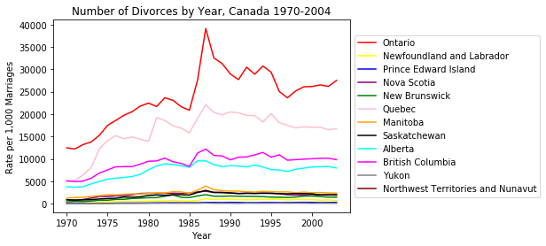

```python
#Graph each province/territory's Divorce Rates by Number of Divorces per year
GEOs = ['Ontario', 'Newfoundland and Labrador', 'Prince Edward Island', 'Nova Scotia', 'New Brunswick', 'Quebec',
        'Manitoba', 'Saskatchewan', 'Alberta', 'British Columbia', 'Yukon', 'Northwest Territories and Nunavut']
colors = ['red', 'yellow', 'blue', 'purple', 'green', 'pink', 'orange', 'black', 'cyan', 'magenta', 'gray',
           'maroon']

for i in range(len(GEOs)):
    pl.plot(vitalStatsDivorce[(vitalStatsDivorce['GEO'] == GEOs[i])]['REF_DATE'],
            vitalStatsDivorce[(vitalStatsDivorce['GEO'] == GEOs[i])]['VALUE'],
            color=colors[i]);

pl.title("Number of Divorces by Year, Canada 1970-2004")
pl.legend(GEOs, loc='center left', bbox_to_anchor=(1.0, 0.5))
pl.xlabel("Year");
pl.ylabel("Rate per 1,000 Marriages");
```

An interesting trend in this data is a significant spike in divorces between 1985 and 1990.

Upon further research, the cause for this spike may have been found:

# The 1986 Divorce Act

In 1986, Canadian Parliament passed the new Divorce Act, replacing the previous version from 1968. From Wikipedia:

[figure not shown]

The act made many changes to how divorces were handled by the government. One change was that divorces would be granted on terms that the couple had been seperated for 1 year. Previously this limit had been 3 years.

To further test how the act influenced divorce rates, let's make a plot for Canada as a whole with labelled significant years and come up with a percentage divorce increase between 1985 and 1987:

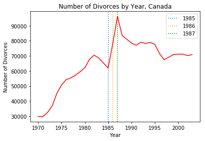

```python
pl.axvline(1985, linestyle=':');
pl.axvline(1986, linestyle=':', color = 'orange');
pl.axvline(1987, linestyle=':', color = 'green');
pl.legend([1985, 1986, 1987])

pl.plot(vitalStatsDivorce[(vitalStatsDivorce['GEO'] == 'Canada')]['REF_DATE'],
        vitalStatsDivorce[(vitalStatsDivorce['GEO'] == 'Canada')]['VALUE'], color='red');

pl.title('Number of Divorces by Year, Canada')
pl.ylabel('Number of Divorces')
pl.xlabel('Year');
```

```python
vsd = vitalStatsDivorce[(vitalStatsDivorce['GEO'] == 'Canada')].set_index('REF_DATE')['VALUE']
print('1985 divorces:', vsd[1985])
print('1986 divorces:', vsd[1986])
print('1987 divorces:', vsd[1987])
print('aproximate percentage divorce increase from 1985 to 1987: '
      ,int(round((vsd[1987] - vsd[1985])/vsd[1985] * 100)), '%', sep ='')
```

```
1985 divorces: 61976
1986 divorces: 78304
1987 divorces: 96200
aproximate percentage divorce increase from 1985 to 1987: 55%
```

Measuring the number of divorces alone isn't the best way to analyze this data. To get a better representation, let's adjust for married population. We can find that data from the 'Estimates of population, by marital status, age group and sex for July 1, Canada, provinces and territories' dataset.

```python
estPopByMaritalStat = pd.read_csv('estimatePopulationByMaritalStatus.csv', low_memory=False);
# print the size of the dataset
print(estPopByMaritalStat.shape)
#filter data for only married population for all Canada
marriedPopulationCanada = estPopByMaritalStat[(popByMaritalStatus['GEO'] == 'Canada') &
                                               (popByMaritalStatus['Sex'] == 'Both sexes') &
                                               (popByMaritalStatus['Age group'] == 'All ages') &
                                               (popByMaritalStatus['Marital status'] == 'Married') &
                                               (popByMaritalStatus['Type of marital status'] == 'Marital status')]
```

```
(1070880, 18)
```

```python
#trim both datasets to include the same years and make new series to hold divorces as a percentage of married population
canadaDivorces = vsd[vsd.index >= 1971]
canadaMarriedPop = marriedPopulationCanada[marriedPopulationCanada['REF_DATE'] <= 2003].set_index('REF_DATE')['VALUE']
canadaDivorcesByMarriedPop = canadaDivorces / canadaMarriedPop * 100
```

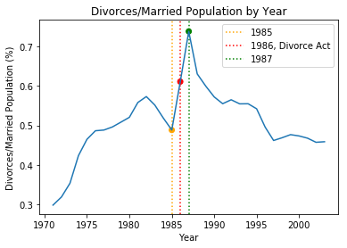

```python
# plot divorces/married population and years 1985-1987
pl.axvline(1985, linestyle=':', color = 'orange');
pl.axvline(1986, linestyle=':', color = 'red');
pl.axvline(1987, linestyle=':', color = 'green');

pl.plot(canadaDivorcesByMarriedPop);
#plot pooints on the line for 1985, 1986 and 1987
pl.scatter([1985,1986,1987], canadaDivorcesByMarriedPop[(canadaDivorcesByMarriedPop.index >= 1985)
                                & (canadaDivorcesByMarriedPop.index <= 1987)], color = ['orange', 'red', 'green']);
pl.legend(['1985', '1986, Divorce Act', '1987']);

pl.title('Divorces/Married Population by Year')
pl.ylabel('Divorces/Married Population (%)')
pl.xlabel('Year');
```

```python
print('Divorces/Married Population:\n1985:', round(canadaDivorcesByMarriedPop[1985],2)
      , '\n1986:', round(canadaDivorcesByMarriedPop[1986], 2)
      , '\n1987:', round(canadaDivorcesByMarriedPop[1987], 2))
```

```
Divorces/Married Population:
1985: 0.49
1986: 0.61
1987: 0.74
```

The spike is even clearer in this graph, with a .49% Divorce rate in 1985 and .74% in 1987. We can also see that this rate drops quickly and decreases over time. From this, we can extrapolate that the 1986 Divorce Act temporarily increased divorces, but did not have a permanent effect on the divorce rate.

# Conclusion

The main point of interest in this data is an obvious correlation between the revised Divorce Act of Canada and the large increase in divorces in 1986, 1987 and 1988. The 1986 Divorce Act removed restrictions for being granted a divorce. It appears that many married couples were divorced because of this. Perhaps they did not meet the 3-year seperation required as cause for divorce that was required prior to 1986.

This trend did not last, however. Divorce rates plunged and levelled off in the early 1990's before dropping again and levelling off in the late 90's/early 2000's.

A conclusion to be drawn from this is that loosening divorce laws can cause temporary rises in divorces, but could be inconsequential in the long term. This analysis could be useful to governments, as it implies that strict divorce laws do not result in lower divorce rates, and loosening divorce restrictions only has short-term consequences. This analysis could be taken to show that government policy has little effect on personal relationships. Perhaps the loosening of divorce restrictions could make the world a better place.